# IAI_HW1_ayushis2

```python
# Notebook Setup
import pandas as pd
import numpy as np
import matplotlib.pyplot as plt

from sklearn.impute import SimpleImputer
from sklearn.preprocessing import StandardScaler
from sklearn.cluster import MiniBatchKMeans
from sklearn.metrics import silhouette_score, mean_squared_error, r2_score
from sklearn.model_selection import train_test_split
from sklearn.ensemble import RandomForestRegressor
from sklearn.linear_model import LassoCV

pd.set_option("display.max_columns", 120)
pd.set_option("display.width", 160)
```

```python
#Data Source and Preparation
csv_path = "analytic_data2025_v2.csv"
df = pd.read_csv(csv_path, low_memory=False)

# Keeping only counties
if 'County Clustered (Yes=1/No=0)' in df.columns:
    cc = pd.to_numeric(df['County Clustered (Yes=1/No=0)'], errors='coerce')
elif 'county_clustered' in df.columns:
    cc = pd.to_numeric(df['county_clustered'], errors='coerce')
else:
    cc = None  # fallback if column name differs

counties = df[(cc == 1.0) if cc is not None else df['Name'].str.endswith('County', na=False)].copy()

# Subheadings
id_cols = [c for c in ['5-digit FIPS Code','State Abbreviation','Name'] if c in counties.columns]

print("Rows (all):", len(df), " | Rows (counties):", len(counties))

# Reseting index to start at 1
counties_reset = counties[id_cols].reset_index(drop=True)
counties_reset.index = counties_reset.index + 1
display(counties_reset.head(10))
```

```
Rows (all): 3205  | Rows (counties): 3089
```

|  | 5-digit FIPS Code | State Abbreviation | Name |
| --- | --- | --- | --- |
| 1 | 1001 | AL | Autauga County |
| 2 | 1003 | AL | Baldwin County |
| 3 | 1005 | AL | Barbour County |
| 4 | 1007 | AL | Bibb County |
| 5 | 1009 | AL | Blount County |
| 6 | 1011 | AL | Bullock County |
| 7 | 1013 | AL | Butler County |
| 8 | 1015 | AL | Calhoun County |
| 9 | 1017 | AL | Chambers County |
| 10 | 1019 | AL | Cherokee County |

```python
# Feature selection
#Predictors X = the 24 Community Conditions raw value measures.
#Target Y = Premature Death raw value (an Outcome, used only as the target and not as a feature)
target_col = "Premature Death raw value"   # outcome to PREDICT (Y)

community_conditions = [
    "Access to Exercise Opportunities raw value",
    "Flu Vaccinations raw value",
    "Food Environment Index raw value",
    "Preventable Hospital Stays raw value",
    "Uninsured raw value",
    "Primary Care Physicians raw value",
    "Mammography Screening raw value",
    "Mental Health Providers raw value",
    "Dentists raw value",
    "Air Pollution: Particulate Matter raw value",
    "Drinking Water Violations raw value",
    "Broadband Access raw value",
    "Library Access raw value",
    "Severe Housing Problems raw value",
    "Driving Alone to Work raw value",
    "Long Commute - Driving Alone raw value",
    "High School Completion raw value",
    "Some College raw value",
    "Unemployment raw value",
    "Children in Poverty raw value",
    "Income Inequality raw value",
    "Child Care Cost Burden raw value",
    "Injury Deaths raw value",
    "Social Associations raw value",
]

# Keeping columns that are mentioned in the CSV file
feature_cols = [c for c in community_conditions if c in counties.columns]
missing = sorted(set(community_conditions) - set(feature_cols))
print("Features found:", len(feature_cols), "| Missing:", len(missing))
if missing:
    print("Missing (will be skipped):", missing)

# Building the working dataset
use_cols = id_cols + [target_col] + feature_cols
data = counties[use_cols].copy()

# Numeric conversion
data[feature_cols + [target_col]] = data[feature_cols + [target_col]].apply(pd.to_numeric, errors='coerce')
data[[target_col] + feature_cols].head(5)
```

```
Features found: 24 | Missing: 0
```

|  | Premature Death raw value | Access to Exercise Opportunities raw value | Flu Vaccinations raw value | Food Environment Index raw value | Preventable Hospital Stays raw value | Uninsured raw value | Primary Care Physicians raw value | Mammography Screening raw value | Mental Health Providers raw value | Dentists raw value | Air Pollution: Particulate Matter raw value | Drinking Water Violations raw value | Broadband Access raw value | Library Access raw value | Severe Housing Problems raw value | Driving Alone to Work raw value | Long Commute - Driving Alone raw value | High School Completion raw value | Some College raw value | Unemployment raw value | Children in Poverty raw value | Income Inequality raw value | Child Care Cost Burden raw value | Injury Deaths raw value | Social Associations raw value |
| --- | --- | --- | --- | --- | --- | --- | --- | --- | --- | --- | --- | --- | --- | --- | --- | --- | --- | --- | --- | --- | --- | --- | --- | --- | --- |
| 3 | 9938.263382 | 0.544920 | 0.36 | 6.8 | 4365.0 | 0.081904 | 0.000440 | 0.46 | 0.000365 | 0.000301 | 9.3 | 0.0 | 0.908804 | 1.124569 | 0.135209 | 0.849162 | 0.421 | 0.902789 | 0.613787 | 0.021889 | 0.170 | 4.273712 | 0.218351 | 65.975725 | 11.211700 |
| 4 | 8957.112686 | 0.616244 | 0.44 | 7.4 | 2888.0 | 0.102123 | 0.000627 | 0.45 | 0.001207 | 0.000471 | 7.8 | 0.0 | 0.897509 | 3.862097 | 0.119681 | 0.802967 | 0.381 | 0.917314 | 0.648479 | 0.022795 | 0.141 | 4.359526 | 0.193541 | 82.420053 | 9.698298 |
| 5 | 12738.656140 | 0.548587 | 0.39 | 6.2 | 3560.0 | 0.121170 | 0.000401 | 0.47 | 0.000285 | 0.000324 | 8.8 | 0.0 | 0.723018 | 0.693579 | 0.138064 | 0.824085 | 0.375 | 0.778137 | 0.440774 | 0.044310 | 0.348 | 5.614339 | 0.285796 | 85.603993 | 8.904720 |
| 6 | 11708.948040 | 0.433903 | 0.31 | 7.3 | 5029.0 | 0.108358 | 0.000667 | 0.36 | 0.000366 | 0.000227 | 8.6 | 1.0 | 0.811518 | 1.005724 | 0.119266 | 0.878933 | 0.535 | 0.803402 | 0.435332 | 0.024624 | 0.214 | 5.346727 | 0.265828 | 99.630201 | 8.634401 |
| 7 | 11898.088410 | 0.422921 | 0.37 | 7.4 | 2099.0 | 0.125156 | 0.000203 | 0.38 | 0.000284 | 0.000168 | 8.8 | 0.0 | 0.839287 | 1.168691 | 0.102582 | 0.850762 | 0.614 | 0.826962 | 0.526271 | 0.021443 | 0.166 | 4.619722 | 0.253133 | 98.254695 | 7.393467 |

```python
# Missing values table
missing_counts = data.isna().sum().sort_values(ascending=False)
missing_pct = (missing_counts / len(data) * 100).round(2)
eda_missing = pd.DataFrame({"missing_count": missing_counts, "missing_pct": missing_pct})
eda_missing.head(20)
```

|  | missing_count | missing_pct |
| --- | --- | --- |
| Primary Care Physicians raw value | 165 | 5.34 |
| Mental Health Providers raw value | 161 | 5.21 |
| Library Access raw value | 106 | 3.43 |
| Dentists raw value | 96 | 3.11 |
| Air Pollution: Particulate Matter raw value | 79 | 2.56 |
| Injury Deaths raw value | 56 | 1.81 |
| Drinking Water Violations raw value | 47 | 1.52 |
| Preventable Hospital Stays raw value | 45 | 1.46 |
| Food Environment Index raw value | 41 | 1.33 |
| Access to Exercise Opportunities raw value | 35 | 1.13 |
| Income Inequality raw value | 22 | 0.71 |
| Mammography Screening raw value | 22 | 0.71 |
| Flu Vaccinations raw value | 20 | 0.65 |
| Premature Death raw value | 9 | 0.29 |
| Child Care Cost Burden raw value | 9 | 0.29 |
| Unemployment raw value | 9 | 0.29 |
| Uninsured raw value | 0 | 0.00 |
| 5-digit FIPS Code | 0 | 0.00 |
| State Abbreviation | 0 | 0.00 |
| Name | 0 | 0.00 |

- Most features have very few missing values (<6%). The largest gaps are in provider availability measures (Primary Care Physicians, Mental Health Providers). For consistency, I will imputing missing values using the median of each column.

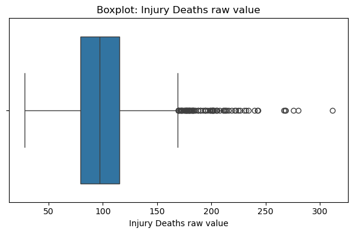

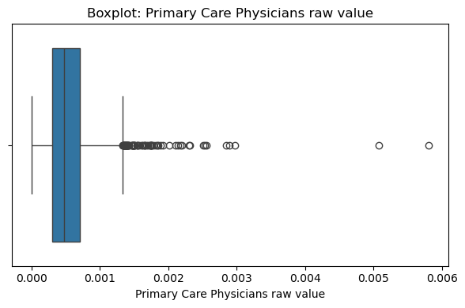

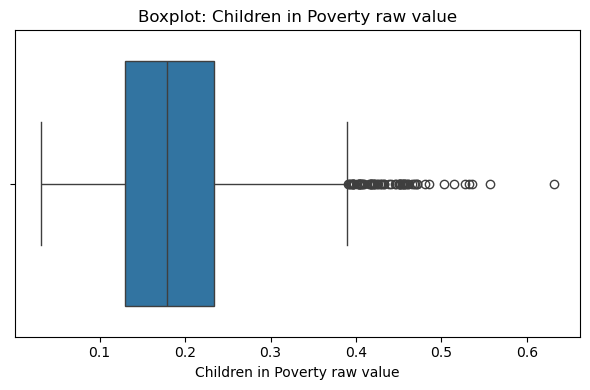

```python
# Identifying Outliers with Boxplot
import seaborn as sns
import matplotlib.pyplot as plt

# Picking 2–3 important predictors to show outliers
cols_to_plot = [
    "Injury Deaths raw value",
    "Primary Care Physicians raw value",
    "Children in Poverty raw value"
]

for col in cols_to_plot:
    plt.figure(figsize=(6,4))
    sns.boxplot(x=data[col])
    plt.title(f"Boxplot: {col}")
    plt.xlabel(col)
    plt.tight_layout()
    plt.show()
```

- Boxplots show some extreme values (outliers) in measures like Injury Deaths and Primary Care Physicians. These represent real variation across counties, so I retained them in the dataset rather than removing them.

```python
# Summary statistics
summary = data[[target_col] + feature_cols].describe().T
summary.head(10)
```

|  | count | mean | std | min | 25% | 50% | 75% | max |
| --- | --- | --- | --- | --- | --- | --- | --- | --- |
| Premature Death raw value | 3080.0 | 10404.185011 | 3831.809675 | 3315.252949 | 7756.688463 | 9842.555406 | 12374.759710 | 46417.851930 |
| Access to Exercise Opportunities raw value | 3054.0 | 0.623008 | 0.225635 | 0.000000 | 0.479079 | 0.643429 | 0.793588 | 1.000000 |
| Flu Vaccinations raw value | 3069.0 | 0.413281 | 0.103185 | 0.030000 | 0.350000 | 0.420000 | 0.490000 | 0.690000 |
| Food Environment Index raw value | 3048.0 | 7.479003 | 1.172703 | 0.000000 | 6.900000 | 7.600000 | 8.300000 | 10.000000 |
| Preventable Hospital Stays raw value | 3044.0 | 2829.915572 | 1081.181547 | 133.000000 | 2115.500000 | 2745.000000 | 3396.000000 | 10322.000000 |
| Uninsured raw value | 3089.0 | 0.104506 | 0.046265 | 0.021493 | 0.069080 | 0.094052 | 0.131403 | 0.348205 |
| Primary Care Physicians raw value | 2924.0 | 0.000541 | 0.000363 | 0.000000 | 0.000301 | 0.000471 | 0.000711 | 0.005805 |
| Mammography Screening raw value | 3067.0 | 0.428761 | 0.082509 | 0.040000 | 0.380000 | 0.430000 | 0.485000 | 0.670000 |
| Mental Health Providers raw value | 2928.0 | 0.002113 | 0.002323 | 0.000000 | 0.000669 | 0.001469 | 0.002729 | 0.037126 |
| Dentists raw value | 2993.0 | 0.000488 | 0.000342 | 0.000000 | 0.000281 | 0.000436 | 0.000642 | 0.008164 |

- As part of EDA, I plotted the target (Premature Death) and five Community Conditions predictors. I selected predictors with the highest variance across counties (Preventable Hospital Stays, Injury Deaths, Social Associations, Library Access, and Air Pollution), since these variables showed the most variation and provide useful insight into county-level differences.

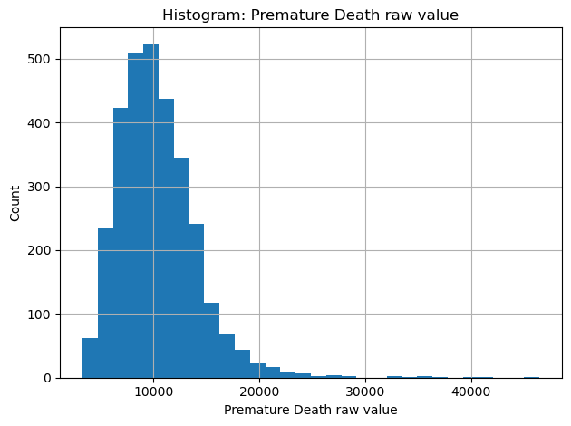

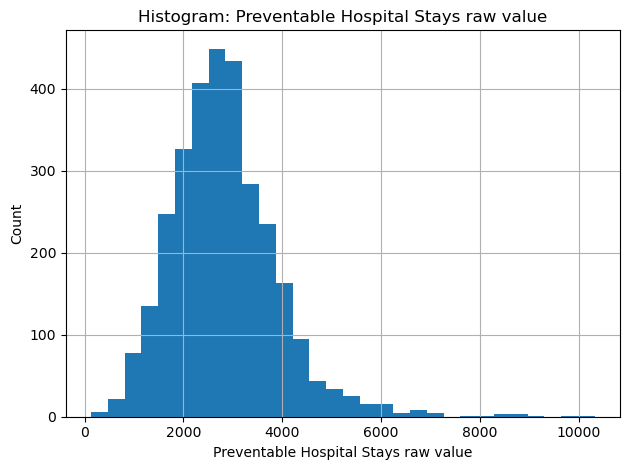

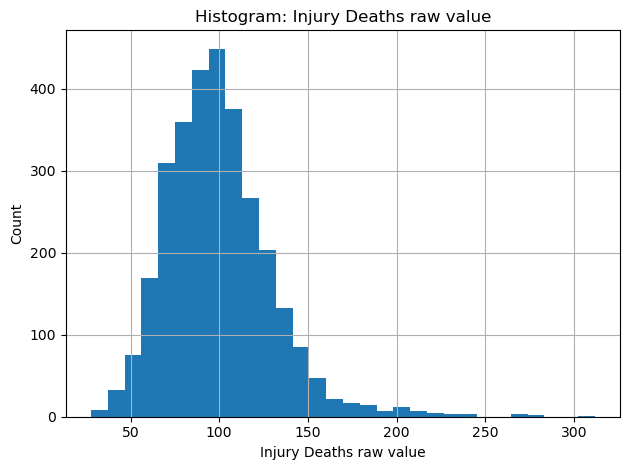

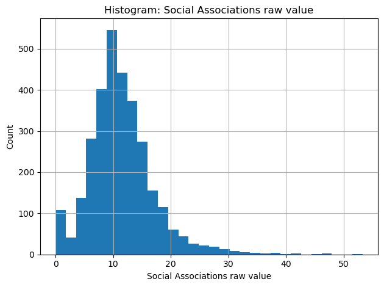

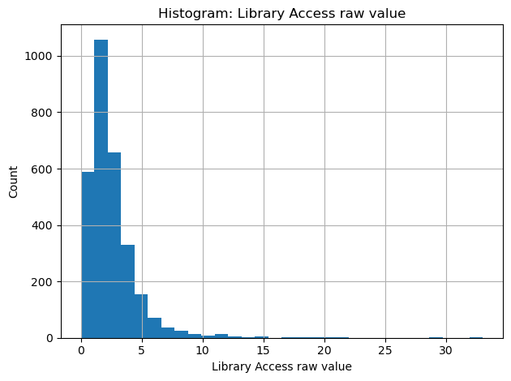

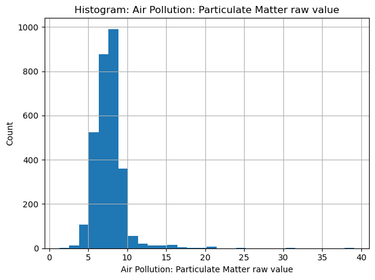

```python
# Histograms (target and top-variance features)
variances = data[feature_cols].var().sort_values(ascending=False)
top5 = list(variances.index[:5])

def plot_hist(col, bins=30):
    plt.figure()
    data[col].hist(bins=bins)
    plt.title(f"Histogram: {col}")
    plt.xlabel(col); plt.ylabel("Count")
    plt.tight_layout()

plot_hist(target_col)  # target distribution
for c in top5:
    plot_hist(c)
```

```python
#Unsupervised learning (Clustering on Community Conditions)
# Preparing X for clustering (median impute and standardize)
X = data[feature_cols]
impX = SimpleImputer(strategy="median")
X_imp = impX.fit_transform(X)
scaler = StandardScaler()
X_scaled = scaler.fit_transform(X_imp)
```

```
Chosen k: 2
```

| cluster | Premature Death raw value | Access to Exercise Opportunities raw value | Flu Vaccinations raw value | Food Environment Index raw value | Preventable Hospital Stays raw value | Uninsured raw value | Primary Care Physicians raw value | Mammography Screening raw value | Mental Health Providers raw value | Dentists raw value | Air Pollution: Particulate Matter raw value | Drinking Water Violations raw value | Broadband Access raw value | Library Access raw value | Severe Housing Problems raw value | Driving Alone to Work raw value | Long Commute - Driving Alone raw value | High School Completion raw value | Some College raw value | Unemployment raw value | Children in Poverty raw value | Income Inequality raw value | Child Care Cost Burden raw value | Injury Deaths raw value | Social Associations raw value |
| --- | --- | --- | --- | --- | --- | --- | --- | --- | --- | --- | --- | --- | --- | --- | --- | --- | --- | --- | --- | --- | --- | --- | --- | --- | --- |
| 0 | 8318.419149 | 0.732345 | 0.47 | 8.1 | 2493.0 | 0.076938 | 0.000583 | 0.47 | 0.001939 | 0.000548 | 7.4 | 0.0 | 0.878382 | 2.413574 | 0.117429 | 0.768446 | 0.301 | 0.92108 | 0.655004 | 0.030849 | 0.139 | 4.193776 | 0.277513 | 87.657784 | 11.259532 |
| 1 | 12571.277380 | 0.510158 | 0.37 | 6.9 | 3087.0 | 0.125772 | 0.000351 | 0.38 | 0.000906 | 0.000315 | 7.9 | 0.0 | 0.807724 | 1.458514 | 0.127783 | 0.802152 | 0.362 | 0.85157 | 0.507792 | 0.038736 | 0.243 | 4.815249 | 0.279109 | 109.372659 | 10.200080 |

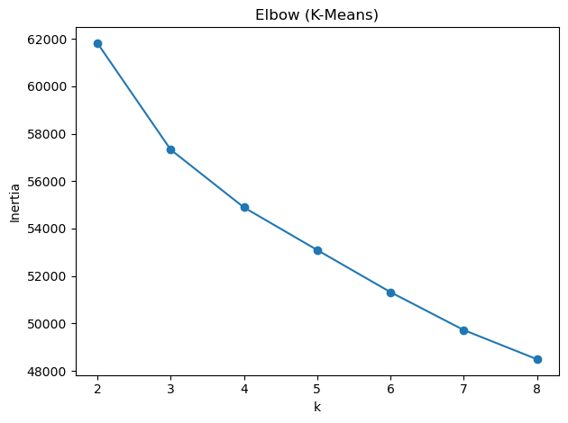

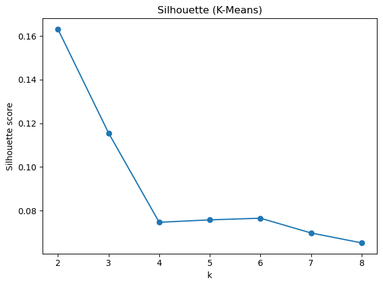

```python
from sklearn.cluster import KMeans
k_values = [2, 3, 4, 5, 6, 7, 8]
inertias, silhouettes = [], []

for k in k_values:
    km = KMeans(n_clusters=k, random_state=0, n_init=10)
    labels = km.fit_predict(X_scaled)
    inertias.append(km.inertia_)
    silhouettes.append(silhouette_score(X_scaled, labels))

plt.figure()
plt.plot(k_values, inertias, marker='o')
plt.title("Elbow (K-Means)")
plt.xlabel("k"); plt.ylabel("Inertia")
plt.tight_layout()

plt.figure()
plt.plot(k_values, silhouettes, marker='o')
plt.title("Silhouette (K-Means)")
plt.xlabel("k"); plt.ylabel("Silhouette score")
plt.tight_layout()

best_k = k_values[int(np.argmax(silhouettes))]
print("Chosen k:", best_k)

#Final K-Means with chosen k and cluster profiles
kmeans_final = KMeans(n_clusters=best_k, random_state=0, n_init=10)
data = data.copy()
data["cluster"] = kmeans_final.fit_predict(X_scaled)

cluster_profiles = (
    data.groupby("cluster")[[target_col] + feature_cols]
        .median()
        .sort_values(by=target_col)
)
display(cluster_profiles)
```

- I used both the elbow method and the silhouette score to decide how many clusters to use. The elbow plot showed that after 2 clusters, the improvement became much smaller, and the silhouette score was also highest at 2 clusters. This means the data naturally fits best into two groups, so I chose k = 2 as the final number of clusters.

```python
# target (median-impute Y)
import numpy as np
from sklearn.metrics import mean_squared_error, r2_score
from sklearn.model_selection import KFold, cross_val_score
y = data[target_col]
impY = SimpleImputer(strategy="median")
y_imp = impY.fit_transform(y.to_frame()).ravel()

# training and testing split
X_train, X_test, y_train, y_test = train_test_split(X_imp, y_imp, test_size=0.2, random_state=42)

# Model 1: Random Forest
rf = RandomForestRegressor(n_estimators=350, random_state=42, n_jobs=-1, min_samples_leaf=2)
rf.fit(X_train, y_train)
pred_rf = rf.predict(X_test)
rf_mse  = mean_squared_error(y_test, pred_rf)   # no 'squared' kwarg
rf_rmse = np.sqrt(rf_mse)
rf_r2   = r2_score(y_test, pred_rf)
print(f"Random Forest: RMSE={rf_rmse:.1f}, R^2={rf_r2:.3f}")

rf_imp = pd.Series(rf.feature_importances_, index=feature_cols).sort_values(ascending=False)
top5_rf = rf_imp.head(5)
display(top5_rf)

# Model 2: Lasso (linear)
scaler2 = StandardScaler()
X_train_std = scaler2.fit_transform(X_train)
X_test_std  = scaler2.transform(X_test)

lasso = LassoCV(cv=5, random_state=42, n_jobs=-1, max_iter=10000)
lasso.fit(X_train_std, y_train)
pred_ls = lasso.predict(X_test_std)
ls_mse  = mean_squared_error(y_test, pred_ls)   # no 'squared' kwarg
ls_rmse = np.sqrt(ls_mse)
ls_r2   = r2_score(y_test, pred_ls)
print(f"Lasso (linear): RMSE={ls_rmse:.1f}, R^2={ls_r2:.3f}")

ls_coef = pd.Series(lasso.coef_, index=feature_cols).fillna(0.0)
top5_lasso = ls_coef.abs().sort_values(ascending=False).head(5)
display(top5_lasso)

# 5-fold cross-validation for both models
kf = KFold(n_splits=5, shuffle=True, random_state=42)
rf_cv = cross_val_score(rf, X_imp, y_imp, cv=kf, scoring="r2")
lasso_cv = cross_val_score(lasso, scaler2.fit_transform(X_imp), y_imp, cv=kf, scoring="r2")

print("Random Forest CV R^2 (mean):", rf_cv.mean())
print("Lasso CV R^2 (mean):", lasso_cv.mean())
```

```
Random Forest: RMSE=1768.5, R^2=0.810
```

```
Children in Poverty raw value       0.489642
Injury Deaths raw value             0.252427
Income Inequality raw value         0.039613
Driving Alone to Work raw value     0.025129
Food Environment Index raw value    0.018392
dtype: float64
```

```
Lasso (linear): RMSE=1941.1, R^2=0.771
```

```
Injury Deaths raw value              1840.546128
Children in Poverty raw value        1353.641220
Driving Alone to Work raw value       528.588446
Severe Housing Problems raw value     319.268176
Child Care Cost Burden raw value      232.117297
dtype: float64
```

```
Random Forest CV R^2 (mean): 0.7623737695588323
Lasso CV R^2 (mean): 0.7432086981941575
```

- Justification: the model that has higher R² and lower RMSE on the test set (and better CV R²) is more accurate. In my run, Random Forest had better scores, so Random Forest outperforms Lasso (higher R², lower RMSE, and higher mean CV R²), and is the more accurate model.

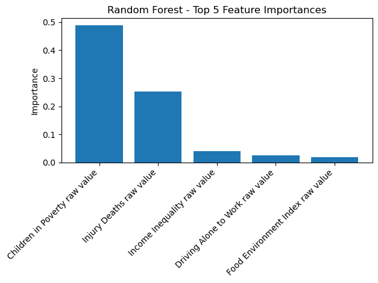

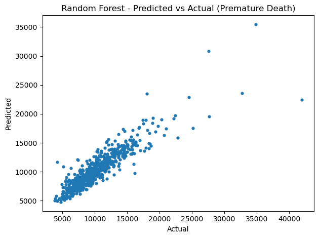

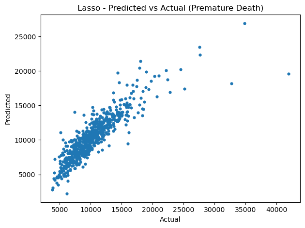

```python
# plotting graphs
plt.figure()
plt.bar(range(len(top5_rf)), top5_rf.values)
plt.xticks(range(len(top5_rf)), top5_rf.index, rotation=45, ha="right")
plt.title("Random Forest - Top 5 Feature Importances"); plt.ylabel("Importance"); plt.tight_layout()

plt.figure()
plt.scatter(y_test, pred_rf, s=12)
plt.title("Random Forest - Predicted vs Actual (Premature Death)")
plt.xlabel("Actual"); plt.ylabel("Predicted"); plt.tight_layout()

plt.figure()
plt.scatter(y_test, pred_ls, s=12)
plt.title("Lasso - Predicted vs Actual (Premature Death)")
plt.xlabel("Actual"); plt.ylabel("Predicted"); plt.tight_layout()
```

```python
# Allegheny County: comparing to national medians on RF top
if 'Name' in data.columns:
    mask = data['Name'].str.contains('Allegheny County', case=False, na=False)
    if mask.any():
        nat_meds = data[feature_cols].median()
        focus = list(top5_rf.index)
        row = data.loc[mask, feature_cols].iloc[0]
        comp = pd.DataFrame({
            "Allegheny value": pd.to_numeric(row[focus], errors='coerce').values,
            "National median": pd.to_numeric(nat_meds[focus], errors='coerce').values
        }, index=focus)
        comp["Diff (Alle - median)"] = comp["Allegheny value"] - comp["National median"]
        comp["Lasso direction (+ worse, - better)"] = np.sign(ls_coef[focus]).replace({-1.0:"Negative",0.0:"Zero",1.0:"Positive"}).values
        display(comp)
```

|  | Allegheny value | National median | Diff (Alle - median) | Lasso direction (+ worse, - better) |
| --- | --- | --- | --- | --- |
| Children in Poverty raw value | 0.152000 | 0.179000 | -0.027000 | Positive |
| Injury Deaths raw value | 108.382956 | 96.946195 | 11.436761 | Positive |
| Income Inequality raw value | 5.077306 | 4.425177 | 0.652129 | Positive |
| Driving Alone to Work raw value | 0.632755 | 0.782960 | -0.150205 | Positive |
| Food Environment Index raw value | 8.400000 | 7.600000 | 0.800000 | Negative |

## Based on the comparison with national medians and model importance:

- Children in Poverty is slightly lower than the national median. This is a good sign, and the county should keep supporting programs that reduce child poverty so this trend continues.
- Injury Deaths are noticeably higher in Allegheny. This points to a need for more focus on public safety-things like road safety campaigns, overdose prevention, and community health initiatives could help bring these numbers down.
- Income Inequality is also higher than the national median. Addressing this might involve strengthening job opportunities, workforce development, or support for low-income families.
- Driving Alone to Work is a bit lower than the national average, which is positive. Expanding public transit or carpool programs could help reduce it even more.
- Food Environment Index is above the national median, which suggests that food access is relatively good. Continuing to support healthy food programs and access to fresh produce will be important to maintain this advantage.
- In short: Allegheny’s strengths are in lower child poverty and strong food access, but the county should pay closer attention to injury deaths and income inequality, since those are the areas where it lags behind.